# Deep Learning - MLPClassifier

Oldemar Rodríguez

2022-11-03

# Introducción

[figure not shown]

### Para el modelo de Multi-layer Perceptron classifier (MLPClassifier) vamos a utilizar la función `MLPClassifier` del paquete `sklearn`. Para mayor información de la función puede ingresar al siguiente enlace: https://scikit-learn.org/stable/modules/generated/sklearn.neural_network.MLPClassifier.html

### Paquetes a utilizar

```python
import os
import pandas as pd
import numpy  as np
import matplotlib.pyplot as plt
from sklearn.model_selection import train_test_split
from sklearn.neural_network import MLPClassifier
from sklearn.preprocessing import StandardScaler
from sklearn.metrics import confusion_matrix
from pandas import DataFrame
from matplotlib import colors as mcolors
import warnings
warnings.filterwarnings('ignore')
```

# Clase Analisis_Predictivo

```python
from pandas import DataFrame
import seaborn as sns

class Analisis_Predictivo:

    def __init__(self,datos:DataFrame, predecir:str, predictoras = [],
                 modelo = None,train_size = 80,random_state = None):
        '''
        datos: Datos completos y listos para construir un modelo

        modelo: Instancia de una Clase de un método de clasificación(KNN,Árboles,SVM,etc).
        Si no especifica un modelo no podrá utilizar el método fit_n_review()

        predecir: Nombre de la variable a predecir

        predictoras: Lista de los nombres de las variables predictoras.
        Si vacío entonces utiliza todas las variables presentes excepto la variable a predecir.

        train_size: Proporción de la tabla de entrenamiento respecto a la original.

        random_state: Semilla aleatoria para la división de datos(training-testing).
        '''
        self.__datos = datos
        self.__predecir = predecir
        self.__predictoras = predictoras
        self.__modelo = modelo
        self.__random_state = random_state
        if modelo != None:
            self.__train_size = train_size
            self._training_testing()

    @property
    def datos(self):
        return self.__datos

    @property
    def predecir(self):
        return self.__predecir

    @property
    def predictoras(self):
        return self.__predictoras

    @property
    def modelo(self):
        return self.__modelo

    @property
    def random_state(self):
        return self.__random_state

    @property
    def train_size(self):
        return self.__train_size

    @datos.setter
    def datos(self, datos):
        self.__datos = datos

    @predecir.setter
    def predecir(self, predecir):
        self.__predecir = predecir

    @predictoras.setter
    def predictoras(self, predictoras):
        self.__predictoras = predictoras

    @modelo.setter
    def modelo(self, modelo):
        self.__modelo = modelo

    @random_state.setter
    def random_state(self, random_state):
        self.__random_state = random_state

    @train_size.setter
    def train_size(self, train_size):
        self.__train_size = train_size

    def _training_testing(self):
        if len(self.predictoras) == 0:
            X = self.datos.drop(columns=[self.predecir])
        else:
            X = self.datos[self.predictoras]

        y = self.datos[self.predecir].values

        train_test = train_test_split(X, y, train_size=self.train_size,
                                      random_state=self.random_state)
        self.X_train, self.X_test,self.y_train, self.y_test = train_test

    def fit_predict(self):
        if(self.modelo != None):
            self.modelo.fit(self.X_train,self.y_train)
            return self.modelo.predict(self.X_test)

    def fit_predict_resultados(self, imprimir = True):
        if(self.modelo != None):
            y = self.datos[self.predecir].values
            prediccion = self.fit_predict()
            MC = confusion_matrix(self.y_test, prediccion)
            indices = self.indices_general(MC,list(np.unique(y)))
            if imprimir == True:
                for k in indices:
                    print("\n%s:\n%s"%(k,str(indices[k])))

            return indices

    def indices_general(self,MC, nombres = None):
        "Método para calcular los índices de calidad de la predicción"
        precision_global = np.sum(MC.diagonal()) / np.sum(MC)
        error_global = 1 - precision_global
        precision_categoria  = pd.DataFrame(MC.diagonal()/np.sum(MC,axis = 1)).T
        if nombres!=None:
            precision_categoria.columns = nombres
        return {"Matriz de Confusión":MC,
                "Precisión Global":precision_global,
                "Error Global":error_global,
                "Precisión por categoría":precision_categoria}

    def distribucion_variable_predecir(self):
        "Método para graficar la distribución de la variable a predecir"
        variable_predict = self.predecir
        data = self.datos
        colors = list(dict(**mcolors.CSS4_COLORS))
        df = pd.crosstab(index=data[variable_predict],columns="valor") / data[variable_predict].count()
        fig = plt.figure(figsize=(10,9))
        g = fig.add_subplot(111)
        countv = 0
        titulo = "Distribución de la variable %s" % variable_predict
        for i in range(df.shape[0]):
            g.barh(1,df.iloc[i],left = countv, align='center',color=colors[11+i],label= df.iloc[i].name)
            countv = countv + df.iloc[i]
        vals = g.get_xticks()
        g.set_xlim(0,1)
        g.set_yticklabels("")
        g.set_title(titulo)
        g.set_ylabel(variable_predict)
        g.set_xticklabels(['{:.0%}'.format(x) for x in vals])
        countv = 0
        for v in df.iloc[:,0]:
            g.text(np.mean([countv,countv+v]) - 0.03, 1 , '{:.1%}'.format(v), color='black', fontweight='bold')
            countv = countv + v
        g.legend(loc='upper center', bbox_to_anchor=(1.08, 1), shadow=True, ncol=1)

    def poder_predictivo_categorica(self, var:str):
        "Método para ver la distribución de una variable categórica respecto a la predecir"
        data = self.datos
        variable_predict = self.predecir
        df = pd.crosstab(index= data[var],columns=data[variable_predict])
        df = df.div(df.sum(axis=1),axis=0)
        titulo = "Distribución de la variable %s según la variable %s" % (var,variable_predict)
        g = df.plot(kind='barh',stacked=True,legend = True, figsize = (10,9), \
                    xlim = (0,1),title = titulo, width = 0.8)
        vals = g.get_xticks()
        g.set_xticklabels(['{:.0%}'.format(x) for x in vals])
        g.legend(loc='upper center', bbox_to_anchor=(1.08, 1), shadow=True, ncol=1)
        for bars in g.containers:
            plt.setp(bars, width=.9)
        for i in range(df.shape[0]):
            countv = 0
            for v in df.iloc[i]:
                g.text(np.mean([countv,countv+v]) - 0.03, i , '{:.1%}'.format(v), color='black', fontweight='bold')
                countv = countv + v


    def poder_predictivo_numerica(self,var:str):
        "Función para ver la distribución de una variable numérica respecto a la predecir"
        sns.FacetGrid(self.datos, hue=self.predecir, height=6).map(sns.kdeplot, var, shade=True).add_legend()
```

# Ejemplo 1

## Carga de datos

### Se cargan los datos de iris.

```python
datos = pd.read_csv('../datos/iris.csv', delimiter = ';', decimal = ".")
print(datos.shape)
```

```
## (150, 5)
```

```python
print(datos.head())
```

```
##    s.largo  s.ancho  p.largo  p.ancho    tipo
## 0      5.1      3.5      1.4      0.2  setosa
## 1      4.9      3.0      1.4      0.2  setosa
## 2      4.7      3.2      1.3      0.2  setosa
## 3      4.6      3.1      1.5      0.2  setosa
## 4      5.0      3.6      1.4      0.2  setosa
```

```python
print(datos.info())
```

```
## <class 'pandas.core.frame.DataFrame'>
## RangeIndex: 150 entries, 0 to 149
## Data columns (total 5 columns):
##  #   Column   Non-Null Count  Dtype
## ---  ------   --------------  -----
##  0   s.largo  150 non-null    float64
##  1   s.ancho  150 non-null    float64
##  2   p.largo  150 non-null    float64
##  3   p.ancho  150 non-null    float64
##  4   tipo     150 non-null    object
## dtypes: float64(4), object(1)
## memory usage: 6.0+ KB
## None
```

## Poder Predictivo

### Creamos una instancia de la clase `Analisis_Predictivo()` sin especificar un modelo.

```python
analisis_Iris = Analisis_Predictivo(datos, predecir = "tipo")
```

### Distribución de la variable a predecir.

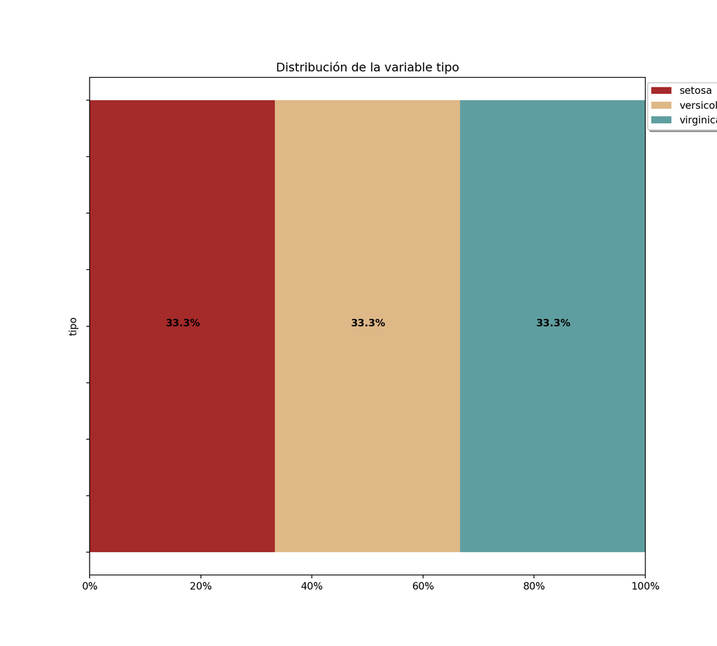

```python
analisis_Iris.distribucion_variable_predecir()
plt.show()
```

### Poder predictivo.

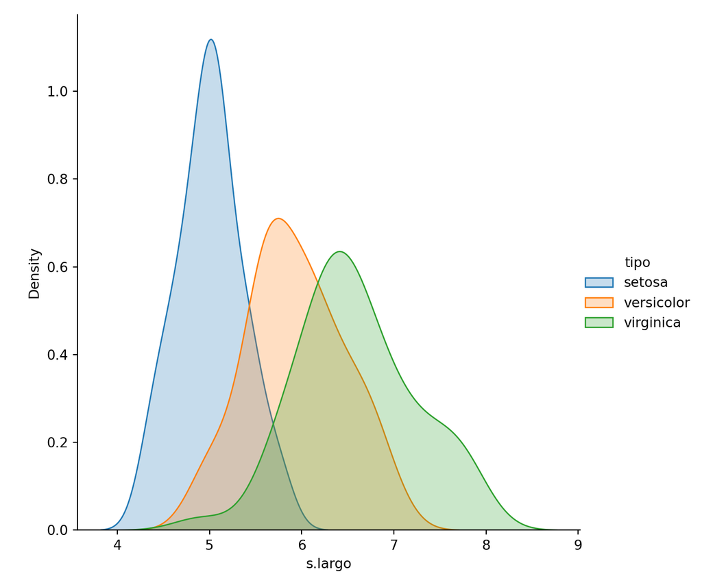

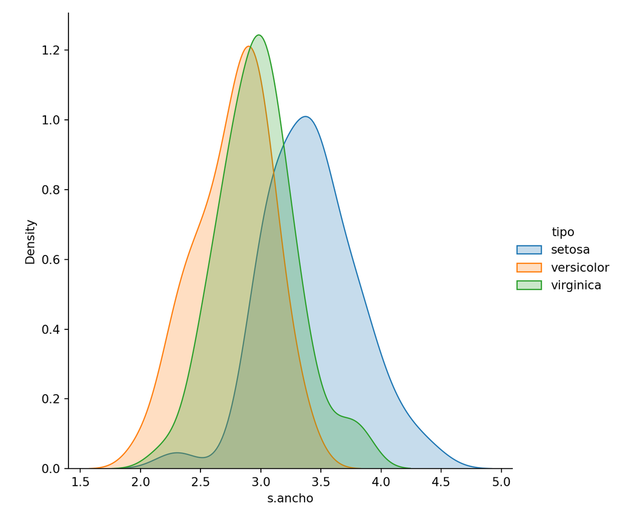

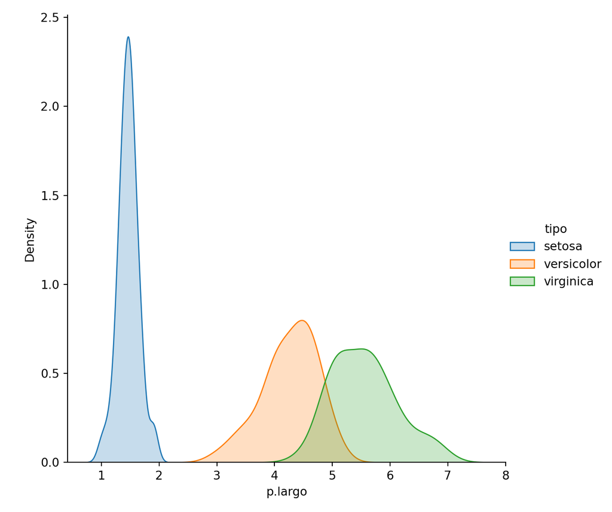

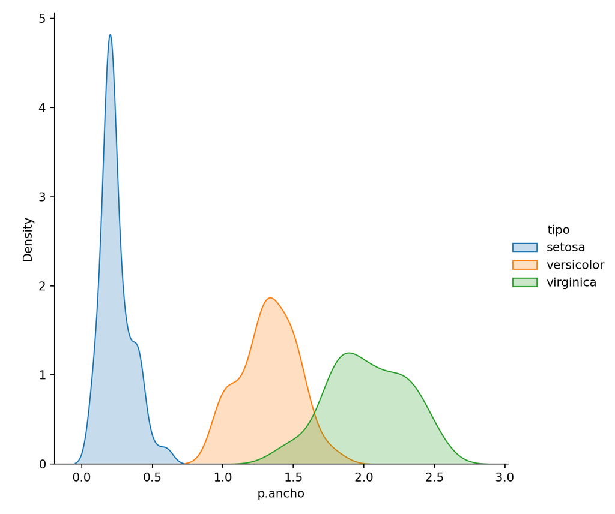

```python
for var in datos.columns[0:4]:
  if(datos[var].dtype in ['float64', 'int64', 'float']):
    analisis_Iris.poder_predictivo_numerica(var)
    plt.show()
  else:
    analisis_Iris.poder_predictivo_categorica(var)
    plt.show()
```

## Predicción

### Creamos una instancia de la clase `MLPClassifier`.

```python
# Usamos los parámetros por defecto
instancia_nnet = MLPClassifier(random_state=0)
```

### Estandarizamos los datos.

```python
datos.iloc[:, 0:4] = StandardScaler().fit_transform(datos.iloc[:, 0:4])
datos
```

```
##       s.largo   s.ancho   p.largo   p.ancho       tipo
## 0   -0.900681  1.032057 -1.341272 -1.312977     setosa
## 1   -1.143017 -0.124958 -1.341272 -1.312977     setosa
## 2   -1.385353  0.337848 -1.398138 -1.312977     setosa
## 3   -1.506521  0.106445 -1.284407 -1.312977     setosa
## 4   -1.021849  1.263460 -1.341272 -1.312977     setosa
## ..        ...       ...       ...       ...        ...
## 145  1.038005 -0.124958  0.819624  1.447956  virginica
## 146  0.553333 -1.281972  0.705893  0.922064  virginica
## 147  0.795669 -0.124958  0.819624  1.053537  virginica
## 148  0.432165  0.800654  0.933356  1.447956  virginica
## 149  0.068662 -0.124958  0.762759  0.790591  virginica
##
## [150 rows x 5 columns]
```

### Creamos una instancia de la clase `Analisis_Predictivo()` especificando un modelo predictivo.

```python
analisis_Iris = Analisis_Predictivo(datos, predecir = "tipo", modelo = instancia_nnet,
                                    train_size = 0.7, random_state = 0)
```

### Entrena el modelo y realiza la predicción sobre la tabla de testing llamando al método `fit_predict()`.

```python
print("Las predicciones en Testing son: {}".format(analisis_Iris.fit_predict()))
```

```
## Las predicciones en Testing son: ['virginica' 'versicolor' 'setosa' 'virginica' 'setosa' 'virginica'
##  'setosa' 'versicolor' 'versicolor' 'versicolor' 'virginica' 'versicolor'
##  'versicolor' 'versicolor' 'versicolor' 'setosa' 'versicolor' 'versicolor'
##  'setosa' 'setosa' 'virginica' 'versicolor' 'setosa' 'setosa' 'virginica'
##  'setosa' 'setosa' 'versicolor' 'versicolor' 'setosa' 'virginica'
##  'versicolor' 'setosa' 'virginica' 'virginica' 'versicolor' 'setosa'
##  'virginica' 'versicolor' 'versicolor' 'virginica' 'setosa' 'virginica'
##  'setosa' 'setosa']
```

### Entrena el modelo y realiza la predicción sobre la tabla de testing, además muestra los principales índices de precisión para medir la calidad del modelo. Esto utilizando el método `fit_predict_resultados()`.

```python
resultados = analisis_Iris.fit_predict_resultados()
```

```
##
## Matriz de Confusión:
## [[16  0  0]
##  [ 0 17  1]
##  [ 0  0 11]]
##
## Precisión Global:
## 0.9777777777777777
##
## Error Global:
## 0.022222222222222254
##
## Precisión por categoría:
##    setosa  versicolor  virginica
## 0     1.0    0.944444        1.0
```

## Predicción con selección de variables

```python
#Instancia de la clase(Modelo)
instancia_nnet = MLPClassifier(random_state=0)

analisis_Iris = Analisis_Predictivo(datos, predecir = "tipo", predictoras = ["p.ancho","p.largo"],
                                    modelo = instancia_nnet, train_size = 0.7, random_state = 0)

#Podemos ver la tabla de training
analisis_Iris.X_train.head()
```

```
##       p.ancho   p.largo
## 60  -0.261193 -0.147093
## 116  0.790591  0.990221
## 144  1.710902  1.103953
## 119  0.396172  0.705893
## 108  0.790591  1.160819
```

```python
#Entrenamos, predecimos y medimos la calidad del modelo generado
resultados = analisis_Iris.fit_predict_resultados()
```

```
##
## Matriz de Confusión:
## [[16  0  0]
##  [ 0 17  1]
##  [ 0  0 11]]
##
## Precisión Global:
## 0.9777777777777777
##
## Error Global:
## 0.022222222222222254
##
## Precisión por categoría:
##    setosa  versicolor  virginica
## 0     1.0    0.944444        1.0
```

## Predicción con selección de parámetros.

### Cantidad de Capas Ocultas: Usando una cantidad diferente de capas ocultas y de nodos.

```python
# 1 capa oculta con 50 nodos.
# IMPORTANTE la coma para indicar que es una tupla. (50,)
# (50) NO es una tupla
# (50,) SÍ es una tupla
nnet1 = MLPClassifier(hidden_layer_sizes= (50,),random_state=0)


# 4 capas ocultas, la primera con 120 nodos,
# la segunda con 80, la tercera con 40 y la última con 20 nodos
nnet4 = MLPClassifier(hidden_layer_sizes= (120, 80, 40, 20),random_state=0)


# 6 capas ocultas, cada una con 5 nodos.
nnet6 = MLPClassifier(hidden_layer_sizes= (5, 5, 5, 5, 5, 5),random_state=0)


# 60 capas ocultas con 6 nodos cada una.
capas = (6,)*60
print("60 capas ocultas con 6 nodos cada una",capas, "\n")
```

```
## 60 capas ocultas con 6 nodos cada una (6, 6, 6, 6, 6, 6, 6, 6, 6, 6, 6, 6, 6, 6, 6, 6, 6, 6, 6, 6, 6, 6, 6, 6, 6, 6, 6, 6, 6, 6, 6, 6, 6, 6, 6, 6, 6, 6, 6, 6, 6, 6, 6, 6, 6, 6, 6, 6, 6, 6, 6, 6, 6, 6, 6, 6, 6, 6, 6, 6)
```

```python
nnet60 = MLPClassifier(hidden_layer_sizes= capas,random_state=0)


# 45 capas ocultas, las primeras 15 con 12 nodos,
# las siguientes 15 con 6 y las últimas 15 con 3 nodos
capas = (12,)*15 + (6,)*15 + (3,)*15
print("45 capas: ", capas, "\n")
```

```
## 45 capas:  (12, 12, 12, 12, 12, 12, 12, 12, 12, 12, 12, 12, 12, 12, 12, 6, 6, 6, 6, 6, 6, 6, 6, 6, 6, 6, 6, 6, 6, 6, 3, 3, 3, 3, 3, 3, 3, 3, 3, 3, 3, 3, 3, 3, 3)
```

```python
nnet45 = MLPClassifier(hidden_layer_sizes= capas,random_state=0)

analisis_Iris = Analisis_Predictivo(datos,predecir= "tipo",modelo = nnet4,
                                       train_size= 0.7, random_state=0)
resultados = analisis_Iris.fit_predict_resultados()
```

```
##
## Matriz de Confusión:
## [[16  0  0]
##  [ 0 17  1]
##  [ 0  0 11]]
##
## Precisión Global:
## 0.9777777777777777
##
## Error Global:
## 0.022222222222222254
##
## Precisión por categoría:
##    setosa  versicolor  virginica
## 0     1.0    0.944444        1.0
```

### Función de Activación: MLPClassifier de Sklearn nos provee de 4 posibles funciones de activación para el parámetro activation. Estos son: `identity`, `logistic`, `tanh` y `relu` (por defecto).

```python
# ==================== relu ===================
nnet = MLPClassifier(hidden_layer_sizes= (50,25) , activation= "relu", random_state=0)
analisis_Iris = Analisis_Predictivo(datos,predecir= "tipo",modelo = nnet,
                                       train_size= 0.7, random_state=0)
resultados = analisis_Iris.fit_predict_resultados()
```

```
##
## Matriz de Confusión:
## [[16  0  0]
##  [ 0 17  1]
##  [ 0  0 11]]
##
## Precisión Global:
## 0.9777777777777777
##
## Error Global:
## 0.022222222222222254
##
## Precisión por categoría:
##    setosa  versicolor  virginica
## 0     1.0    0.944444        1.0
```

```python
# ==================== identity ===================
nnet = MLPClassifier(hidden_layer_sizes= (50,25) , activation= "identity", random_state=0)
analisis_Iris = Analisis_Predictivo(datos,predecir= "tipo",modelo = nnet,
                                       train_size= 0.7, random_state=0)
resultados = analisis_Iris.fit_predict_resultados()
```

```
##
## Matriz de Confusión:
## [[16  0  0]
##  [ 0 17  1]
##  [ 0  0 11]]
##
## Precisión Global:
## 0.9777777777777777
##
## Error Global:
## 0.022222222222222254
##
## Precisión por categoría:
##    setosa  versicolor  virginica
## 0     1.0    0.944444        1.0
```

```python
# ==================== logistic ===================
nnet = MLPClassifier(hidden_layer_sizes= (50,25) , activation= "logistic", random_state=0)
analisis_Iris = Analisis_Predictivo(datos,predecir= "tipo",modelo = nnet,
                                       train_size= 0.7, random_state=0)
resultados = analisis_Iris.fit_predict_resultados()
```

```
##
## Matriz de Confusión:
## [[16  0  0]
##  [ 0  0 18]
##  [ 0  0 11]]
##
## Precisión Global:
## 0.6
##
## Error Global:
## 0.4
##
## Precisión por categoría:
##    setosa  versicolor  virginica
## 0     1.0         0.0        1.0
```

```python
# ==================== tanh ===================
nnet = MLPClassifier(hidden_layer_sizes= (50,25) , activation= "tanh", random_state=0)
analisis_Iris = Analisis_Predictivo(datos,predecir= "tipo",modelo = nnet,
                                       train_size= 0.7, random_state=0)
resultados = analisis_Iris.fit_predict_resultados()
```

```
##
## Matriz de Confusión:
## [[16  0  0]
##  [ 0 17  1]
##  [ 0  0 11]]
##
## Precisión Global:
## 0.9777777777777777
##
## Error Global:
## 0.022222222222222254
##
## Precisión por categoría:
##    setosa  versicolor  virginica
## 0     1.0    0.944444        1.0
```

### El solucionador para la optimización de los pesos: MLPClassifier de Sklearn nos provee de 3 posibles solucionadores para el parámetro solver. Estos son: `lbfgs`, `sgd` y `adam` (por defecto).

```python
# ==================== lbfgs ===================
nnet = MLPClassifier(hidden_layer_sizes= (50,25) , solver= "lbfgs", random_state=0)
analisis_Iris = Analisis_Predictivo(datos,predecir= "tipo",modelo = nnet,
                                       train_size= 0.7, random_state=0)
resultados = analisis_Iris.fit_predict_resultados()
```

```
##
## Matriz de Confusión:
## [[16  0  0]
##  [ 0 17  1]
##  [ 0  0 11]]
##
## Precisión Global:
## 0.9777777777777777
##
## Error Global:
## 0.022222222222222254
##
## Precisión por categoría:
##    setosa  versicolor  virginica
## 0     1.0    0.944444        1.0
```

```python
# ==================== sgd ===================
nnet = MLPClassifier(hidden_layer_sizes= (50,25) , solver= "sgd", random_state=0)
analisis_Iris = Analisis_Predictivo(datos,predecir= "tipo",modelo = nnet,
                                       train_size= 0.7, random_state=0)
resultados = analisis_Iris.fit_predict_resultados()
```

```
##
## Matriz de Confusión:
## [[16  0  0]
##  [ 0  8 10]
##  [ 0  0 11]]
##
## Precisión Global:
## 0.7777777777777778
##
## Error Global:
## 0.2222222222222222
##
## Precisión por categoría:
##    setosa  versicolor  virginica
## 0     1.0    0.444444        1.0
```

```python
# ==================== adam ===================
nnet = MLPClassifier(hidden_layer_sizes= (50,25) , solver= "adam", random_state=0)
analisis_Iris = Analisis_Predictivo(datos,predecir= "tipo",modelo = nnet,
                                       train_size= 0.7, random_state=0)
resultados = analisis_Iris.fit_predict_resultados()
```

```
##
## Matriz de Confusión:
## [[16  0  0]
##  [ 0 17  1]
##  [ 0  0 11]]
##
## Precisión Global:
## 0.9777777777777777
##
## Error Global:
## 0.022222222222222254
##
## Precisión por categoría:
##    setosa  versicolor  virginica
## 0     1.0    0.944444        1.0
```

### Número máximo de iteraciones: En ocasiones un modelo de redes neuronales puede no converger, esto puede ser causado a que necesita un mayor número de iteraciones para el solucionador(número de epochs). Para modificar el número máximo de iteraciones simplemente utilizamos el parámetro `max_iter.` Por defecto el valor es de 200.

```python
# ==================== max_iter = 10 ====================
nnet = MLPClassifier(hidden_layer_sizes= (50,25) , max_iter = 10,random_state=0)
analisis_Iris = Analisis_Predictivo(datos,predecir= "tipo",modelo = nnet,
                                       train_size= 0.7, random_state=0)
resultados = analisis_Iris.fit_predict_resultados()
```

```
##
## Matriz de Confusión:
## [[16  0  0]
##  [15  3  0]
##  [ 7  4  0]]
##
## Precisión Global:
## 0.4222222222222222
##
## Error Global:
## 0.5777777777777777
##
## Precisión por categoría:
##    setosa  versicolor  virginica
## 0     1.0    0.166667        0.0
```

```python
# ==================== max_iter = 300 ====================
nnet = MLPClassifier(hidden_layer_sizes= (50,25) , max_iter = 300,random_state=0)
analisis_Iris = Analisis_Predictivo(datos,predecir= "tipo",modelo = nnet,
                                       train_size= 0.7, random_state=0)
resultados = analisis_Iris.fit_predict_resultados()
```

```
##
## Matriz de Confusión:
## [[16  0  0]
##  [ 0 17  1]
##  [ 0  0 11]]
##
## Precisión Global:
## 0.9777777777777777
##
## Error Global:
## 0.022222222222222254
##
## Precisión por categoría:
##    setosa  versicolor  virginica
## 0     1.0    0.944444        1.0
```

# Ejemplo 2

## Carga de datos

### Se cargan los datos de Scoring de Crédito.

```python
datos = pd.read_csv('../datos/MuestraCredito5000V2.csv', delimiter = ';', decimal = ".")
print(datos.shape)
```

```
## (5000, 6)
```

```python
print(datos.head())
```

```
##    MontoCredito  IngresoNeto  ...  GradoAcademico BuenPagador
## 0         14327            1  ...       Bachiller          Si
## 1        111404            1  ...       Bachiller          Si
## 2         21128            1  ...       Bachiller          Si
## 3         15426            2  ...       Bachiller          Si
## 4         10351            1  ...       Bachiller          Si
##
## [5 rows x 6 columns]
```

```python
print(datos.info())
```

```
## <class 'pandas.core.frame.DataFrame'>
## RangeIndex: 5000 entries, 0 to 4999
## Data columns (total 6 columns):
##  #   Column             Non-Null Count  Dtype
## ---  ------             --------------  -----
##  0   MontoCredito       5000 non-null   int64
##  1   IngresoNeto        5000 non-null   int64
##  2   CoefCreditoAvaluo  5000 non-null   int64
##  3   MontoCuota         5000 non-null   object
##  4   GradoAcademico     5000 non-null   object
##  5   BuenPagador        5000 non-null   object
## dtypes: int64(3), object(3)
## memory usage: 234.5+ KB
## None
```

#### **Nota:** Está tomando erroneamente los datos como numéricos, en este caso se deben convertir las variables categóricas porque en realidad estos numéros son códigos NO es que siempre se deban convertir las variables numéricas a categórica.

```python
# Convierte las variables de object a categórica
datos['IngresoNeto'] = datos['IngresoNeto'].astype('category')
datos['CoefCreditoAvaluo'] = datos['CoefCreditoAvaluo'].astype('category')
datos['MontoCuota'] = datos['MontoCuota'].astype('category')
datos['GradoAcademico'] = datos['GradoAcademico'].astype('category')
# Recodifica las categorías usando números
datos["MontoCuota"] = datos["MontoCuota"].cat.codes
datos["GradoAcademico"] = datos["GradoAcademico"].cat.codes
# Convierte las variables de entero a categórica
datos['MontoCuota'] = datos['MontoCuota'].astype('category')
datos['GradoAcademico'] = datos['GradoAcademico'].astype('category')
print(datos.head())
```

```
##    MontoCredito IngresoNeto  ... GradoAcademico BuenPagador
## 0         14327           1  ...              0          Si
## 1        111404           1  ...              0          Si
## 2         21128           1  ...              0          Si
## 3         15426           2  ...              0          Si
## 4         10351           1  ...              0          Si
##
## [5 rows x 6 columns]
```

```python
print(datos.info())
```

```
## <class 'pandas.core.frame.DataFrame'>
## RangeIndex: 5000 entries, 0 to 4999
## Data columns (total 6 columns):
##  #   Column             Non-Null Count  Dtype
## ---  ------             --------------  -----
##  0   MontoCredito       5000 non-null   int64
##  1   IngresoNeto        5000 non-null   category
##  2   CoefCreditoAvaluo  5000 non-null   category
##  3   MontoCuota         5000 non-null   category
##  4   GradoAcademico     5000 non-null   category
##  5   BuenPagador        5000 non-null   object
## dtypes: category(4), int64(1), object(1)
## memory usage: 98.6+ KB
## None
```

## Poder Predictivo

### Configuramos y creamos nuestras instancias.

```python
analisis_scoring = Analisis_Predictivo(datos, predecir = "BuenPagador",
                                       train_size = 0.75, random_state = 0)
```

### Balance de las clases en la variable a predecir - Problema desvalanceado.

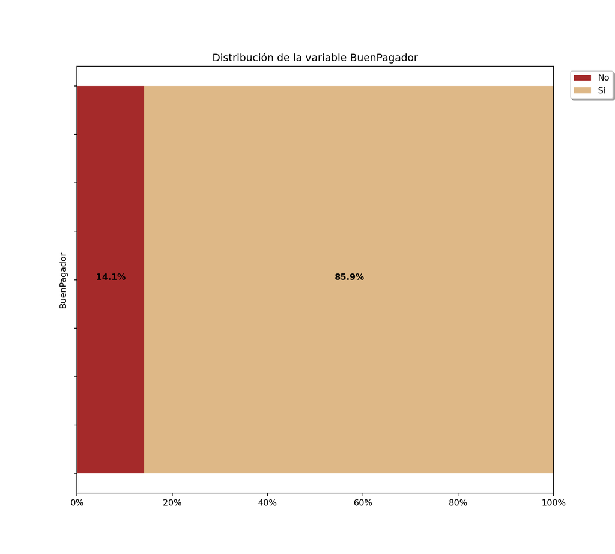

```python
analisis_scoring.distribucion_variable_predecir()
plt.show()
```

### Poder predictivo.

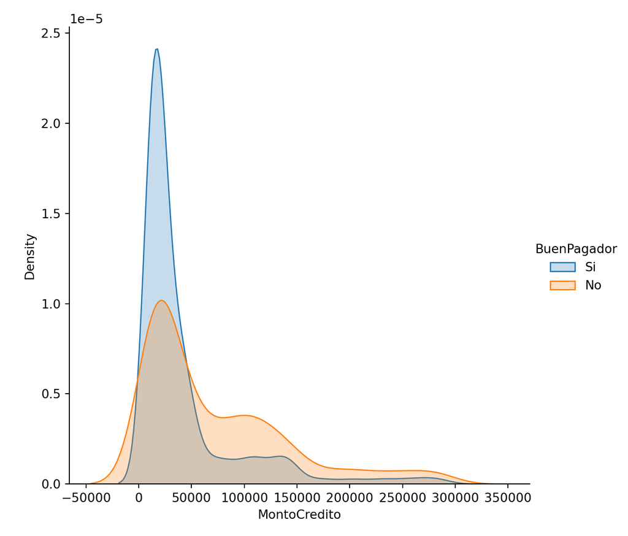

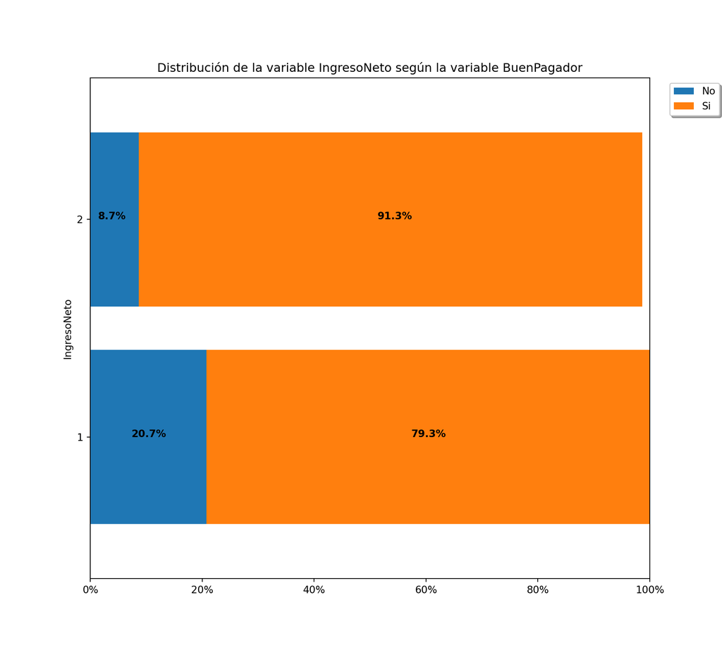

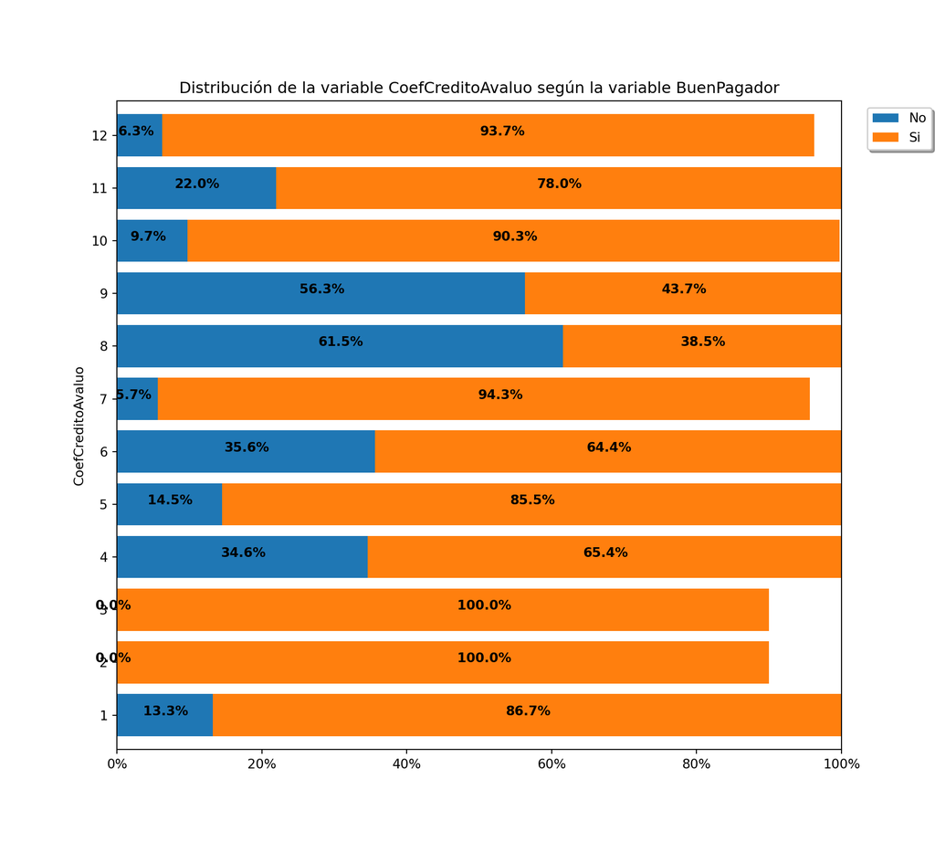

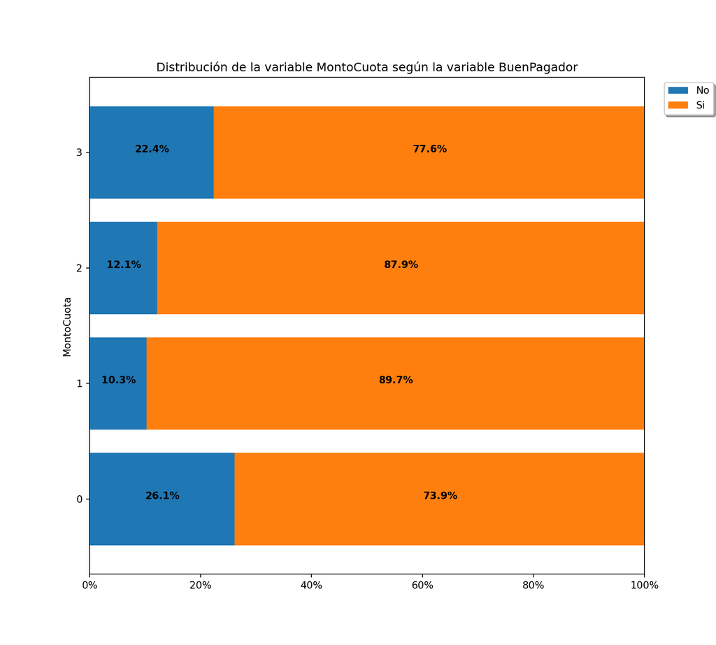

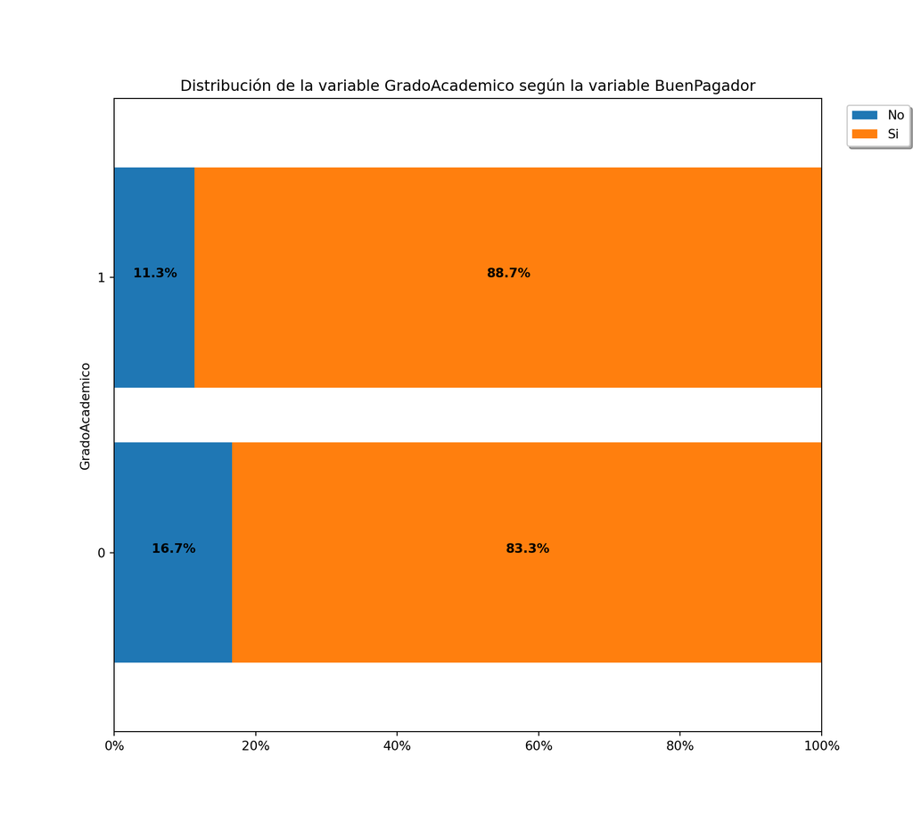

```python
for var in datos.columns[0:5]:
  if(datos[var].dtype in ['float64', 'int', 'float']):
    analisis_scoring.poder_predictivo_numerica(var)
    plt.show()
  else:
    analisis_scoring.poder_predictivo_categorica(var)
    plt.show()
```

## Predicción

### Estandarizamos los datos.

```python
datos.iloc[:, 0:5] = StandardScaler().fit_transform(datos.iloc[:, 0:5])
datos
```

```
##       MontoCredito  IngresoNeto  ...  GradoAcademico  BuenPagador
## 0        -0.585876    -1.107330  ...       -0.966946           Si
## 1         1.166762    -1.107330  ...       -0.966946           Si
## 2        -0.463090    -1.107330  ...       -0.966946           Si
## 3        -0.566035     0.903073  ...       -0.966946           Si
## 4        -0.657659    -1.107330  ...       -0.966946           Si
## ...            ...          ...  ...             ...          ...
## 4995      1.008644    -1.107330  ...        1.034184           No
## 4996      0.884721    -1.107330  ...        1.034184           No
## 4997      0.082830    -1.107330  ...        1.034184           No
## 4998      1.493542    -1.107330  ...        1.034184           No
## 4999     -0.062235     0.903073  ...       -0.966946           No
##
## [5000 rows x 6 columns]
```

### Entrenamos el modelo y medimos la calidad del mismo con la predicción generada con base a la tabla de testing.

```python
nnet = MLPClassifier(hidden_layer_sizes= (50, 25) , max_iter = 8000,
                     activation = "relu", solver= "adam" ,random_state=0)
analisis_scoring = Analisis_Predictivo(datos, predecir = "BuenPagador", modelo = nnet,
                                       train_size = 0.75, random_state = 0)
resultados = analisis_scoring.fit_predict_resultados()
```

```
##
## Matriz de Confusión:
## [[ 125   41]
##  [  16 1068]]
##
## Precisión Global:
## 0.9544
##
## Error Global:
## 0.045599999999999974
##
## Precisión por categoría:
##          No       Si
## 0  0.753012  0.98524
```

### También podemos simplemente guardar los resultados y no imprimir en pantalla.

```python
resultados = analisis_scoring.fit_predict_resultados(imprimir = False)
resultados
```

```
## {'Matriz de Confusión': array([[ 125,   41],
##        [  16, 1068]]), 'Precisión Global': 0.9544, 'Error Global': 0.045599999999999974, 'Precisión por categoría':          No       Si
## 0  0.753012  0.98524}
```

# Ejemplo 3

## Carga de datos

### Se cargan los datos de SAHeart.

```python
datos = pd.read_csv('../datos/SAheart.csv', delimiter = ';', decimal = ".")
print(datos.shape)
```

```
## (462, 10)
```

```python
print(datos.info())
```

```
## <class 'pandas.core.frame.DataFrame'>
## RangeIndex: 462 entries, 0 to 461
## Data columns (total 10 columns):
##  #   Column     Non-Null Count  Dtype
## ---  ------     --------------  -----
##  0   sbp        462 non-null    int64
##  1   tobacco    462 non-null    float64
##  2   ldl        462 non-null    float64
##  3   adiposity  462 non-null    float64
##  4   famhist    462 non-null    object
##  5   typea      462 non-null    int64
##  6   obesity    462 non-null    float64
##  7   alcohol    462 non-null    float64
##  8   age        462 non-null    int64
##  9   chd        462 non-null    object
## dtypes: float64(5), int64(3), object(2)
## memory usage: 36.2+ KB
## None
```

```python
print(datos.head())
```

```
##    sbp  tobacco   ldl  adiposity  famhist  typea  obesity  alcohol  age chd
## 0  160    12.00  5.73      23.11  Present     49    25.30    97.20   52  Si
## 1  144     0.01  4.41      28.61   Absent     55    28.87     2.06   63  Si
## 2  118     0.08  3.48      32.28  Present     52    29.14     3.81   46  No
## 3  170     7.50  6.41      38.03  Present     51    31.99    24.26   58  Si
## 4  134    13.60  3.50      27.78  Present     60    25.99    57.34   49  Si
```

## Poder Predictivo

### Configuramos y creamos nuestras instancias.

```python
analisis_Sheart = Analisis_Predictivo(datos, predecir = "chd",
                                      train_size = 0.8, random_state = 0)
```

### Equilibrio de la variable a predecir.

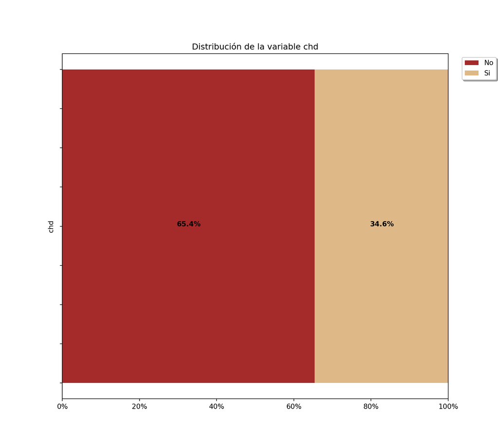

```python
analisis_Sheart.distribucion_variable_predecir()
plt.show()
```

### Poder predictivo.

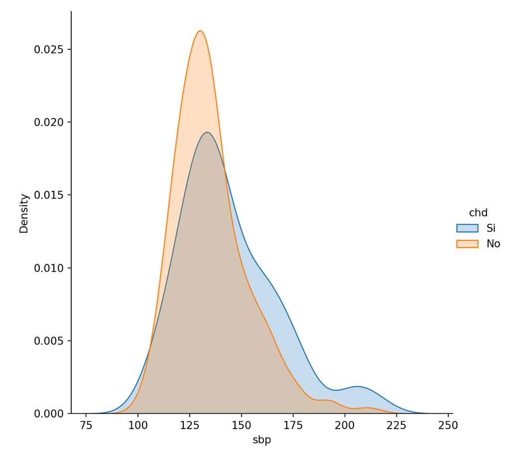

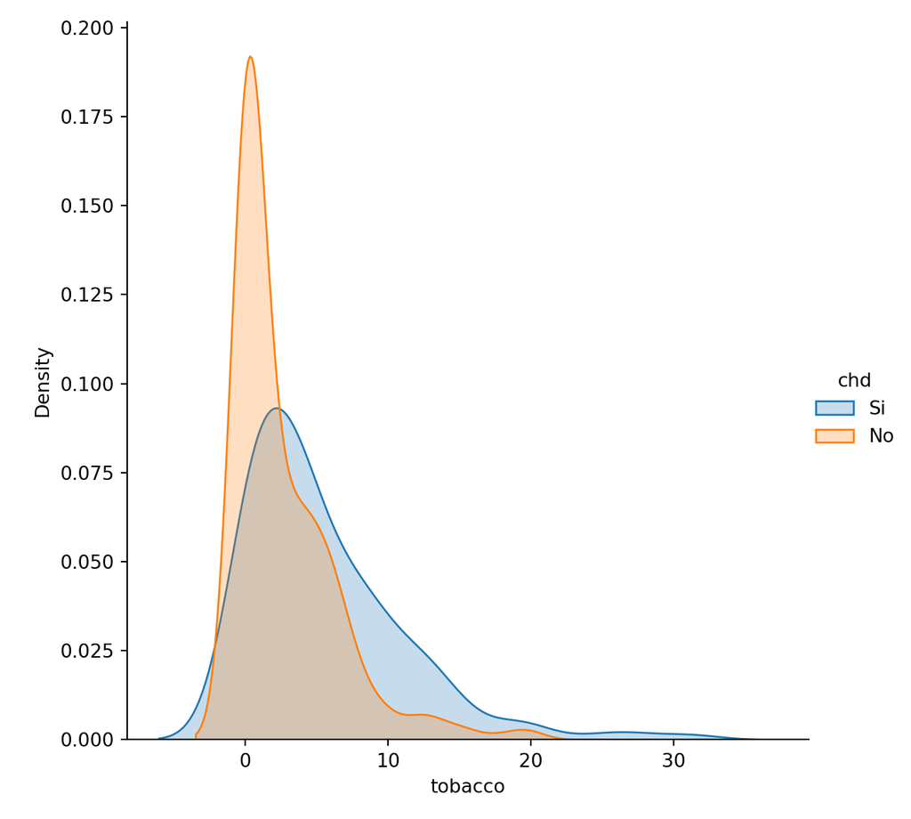

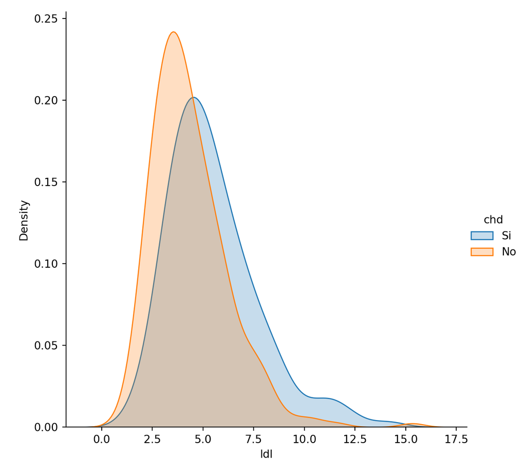

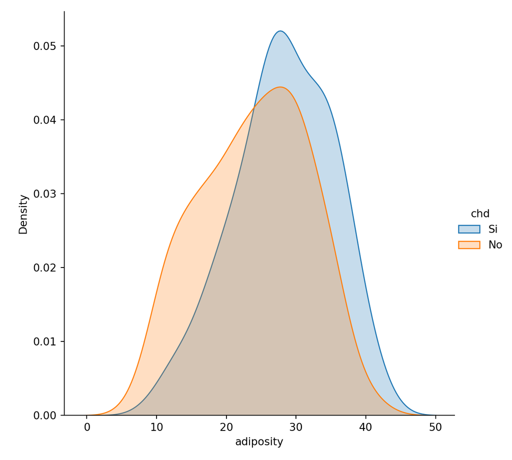

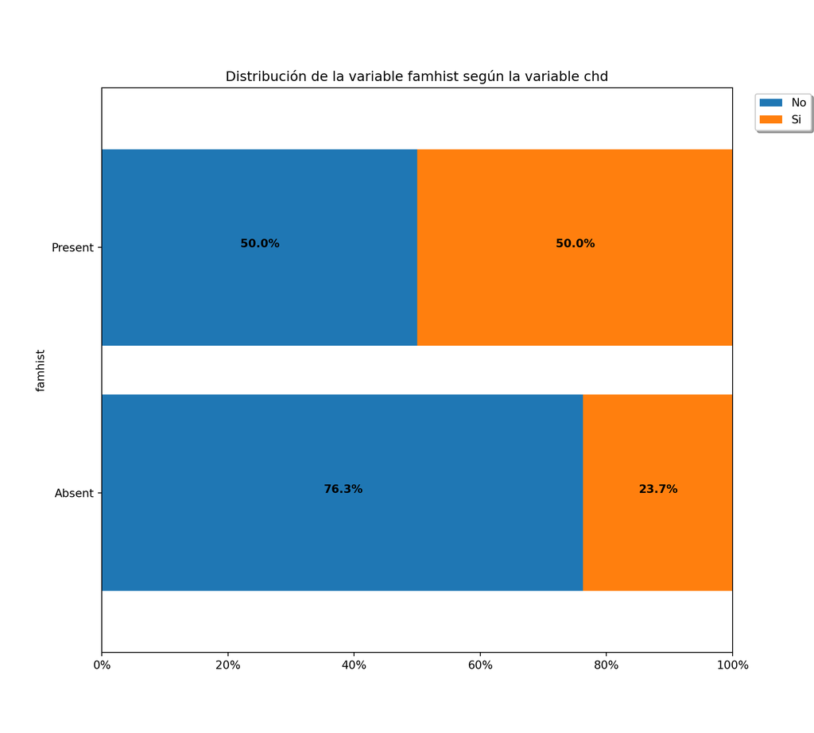

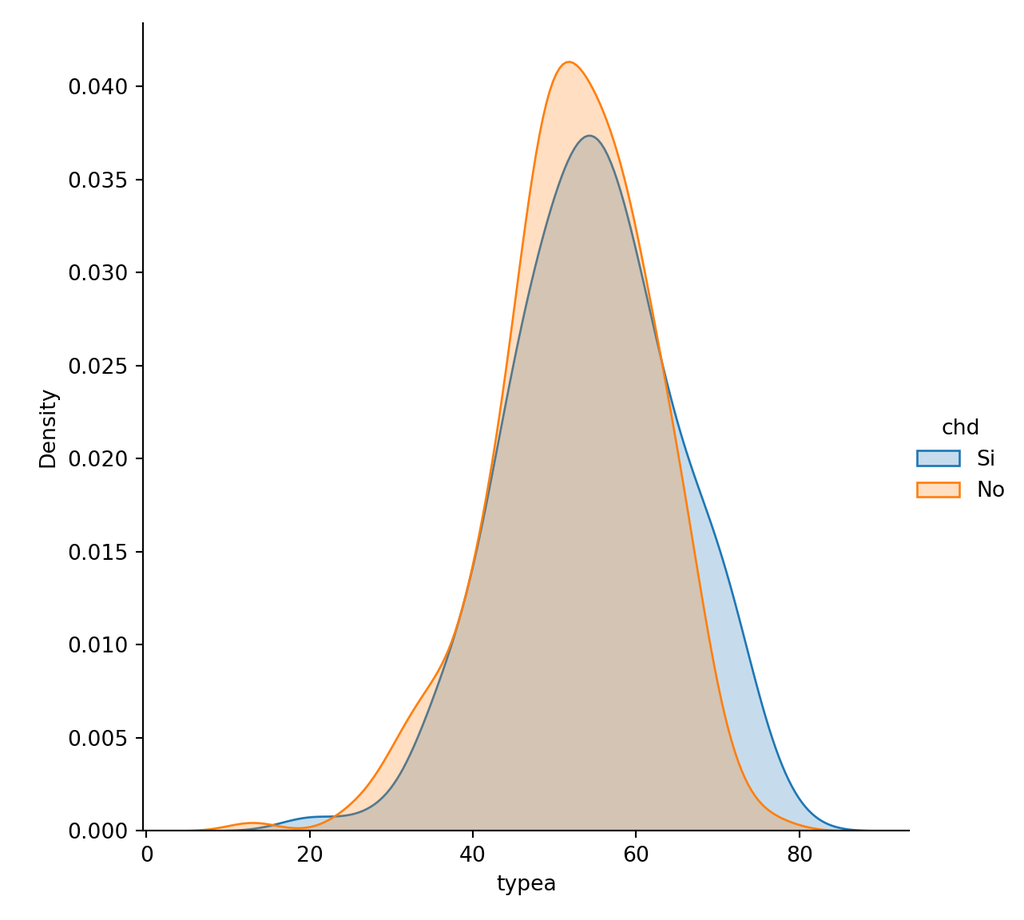

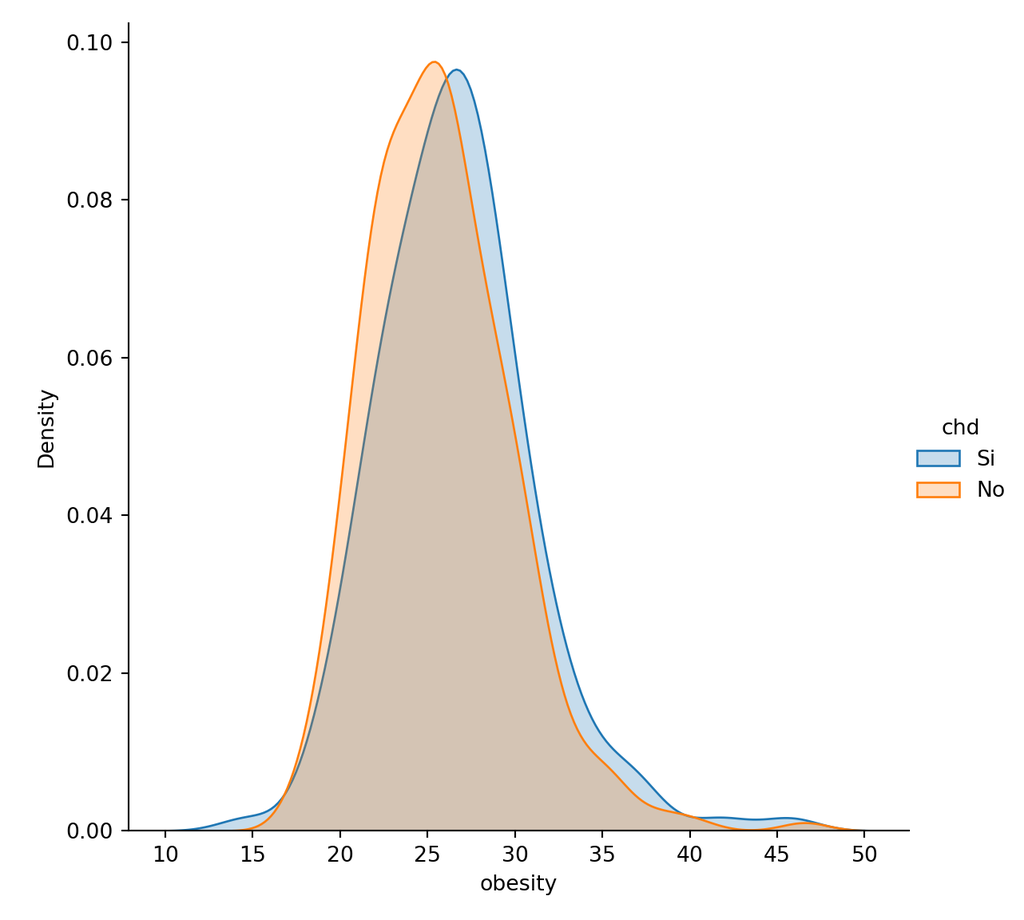

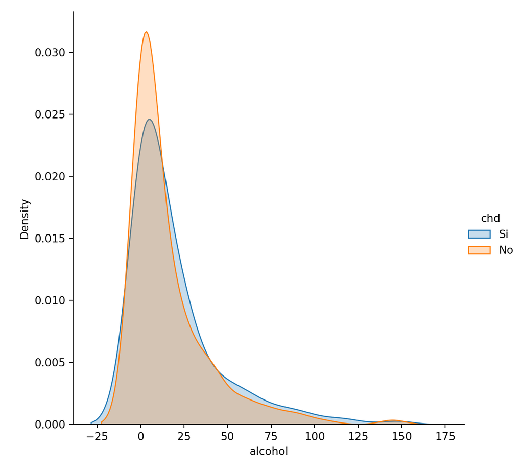

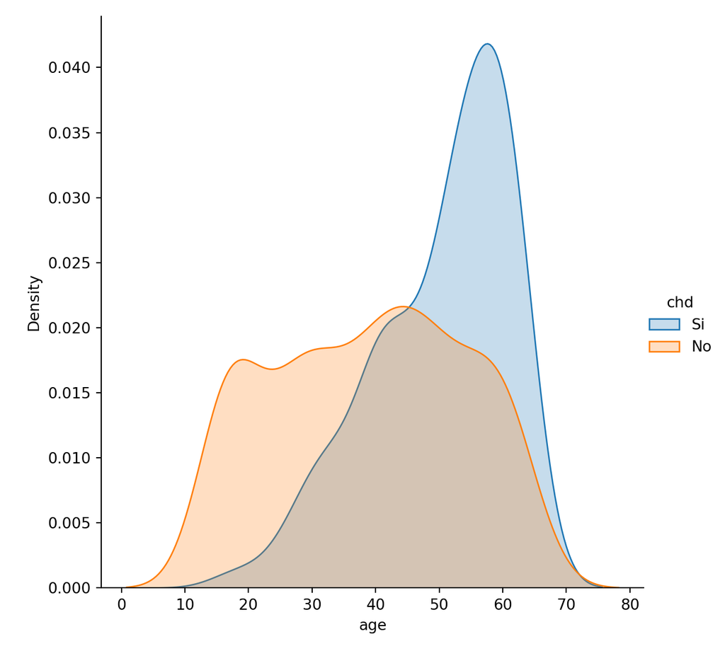

```python
for var in datos.columns[0:9]:
  if(datos[var].dtype in ['float64', 'int', 'float']):
    analisis_Sheart.poder_predictivo_numerica(var)
    plt.show()
  else:
    analisis_Sheart.poder_predictivo_categorica(var)
    plt.show()
```

## Predicción

### Estandarizamos los datos.

```python
datos = pd.get_dummies(data = datos, columns=["famhist"])

datos.loc[:, datos.columns != 'chd'] = StandardScaler().fit_transform(datos.loc[:, datos.columns != 'chd'])
datos
```

```
##           sbp   tobacco       ldl  ...  chd  famhist_Absent  famhist_Present
## 0    1.058564  1.823073  0.478412  ...   Si       -1.185854         1.185854
## 1    0.277089 -0.790237 -0.159680  ...   Si        0.843274        -0.843274
## 2   -0.992806 -0.774980 -0.609245  ...   No       -1.185854         1.185854
## 3    1.546985  0.842264  0.807126  ...   Si       -1.185854         1.185854
## 4   -0.211332  2.171805 -0.599577  ...   Si       -1.185854         1.185854
## ..        ...       ...       ...  ...  ...             ...              ...
## 457  3.696039 -0.705234  0.599263  ...   No        0.843274        -0.843274
## 458  2.133091  0.123004 -0.159680  ...   Si        0.843274        -0.843274
## 459 -1.481228 -0.138545 -1.522877  ...   No        0.843274        -0.843274
## 460 -0.992806  0.384553  3.320823  ...   No        0.843274        -0.843274
## 461 -0.309016 -0.792417  0.038515  ...   Si       -1.185854         1.185854
##
## [462 rows x 11 columns]
```

### Entrena, predice y mide la calidad.

```python
nnet = MLPClassifier(hidden_layer_sizes= (80, 40, 20) , max_iter = 50000,
                     activation = "relu", solver = "adam", random_state = 0)
analisis_Sheart = Analisis_Predictivo(datos, predecir = "chd", modelo = nnet,
                                      train_size = 0.8, random_state = 0)
resultados = analisis_Sheart.fit_predict_resultados()
```

```
##
## Matriz de Confusión:
## [[50 11]
##  [17 15]]
##
## Precisión Global:
## 0.6989247311827957
##
## Error Global:
## 0.30107526881720426
##
## Precisión por categoría:
##          No       Si
## 0  0.819672  0.46875
```

### Con otra función de activación - tanh

```python
nnet = MLPClassifier(hidden_layer_sizes= (80,40,20) , max_iter = 50000,
                     activation = "tanh", solver= "adam" ,random_state=0)
analisis_Sheart = Analisis_Predictivo(datos,predecir="chd",modelo=nnet,
                                          train_size=0.8,random_state=0)
resultados = analisis_Sheart.fit_predict_resultados()
```

```
##
## Matriz de Confusión:
## [[48 13]
##  [20 12]]
##
## Precisión Global:
## 0.6451612903225806
##
## Error Global:
## 0.3548387096774194
##
## Precisión por categoría:
##          No     Si
## 0  0.786885  0.375
```

### Con otro optimizador - lbfgs

```python
nnet = MLPClassifier(hidden_layer_sizes= (80,40,20) , max_iter = 50000,
                     activation = "relu", solver= "lbfgs" ,random_state=0)
analisis_Sheart = Analisis_Predictivo(datos,predecir="chd",modelo=nnet,
                                          train_size=0.8,random_state=0)
resultados = analisis_Sheart.fit_predict_resultados()
```

```
##
## Matriz de Confusión:
## [[49 12]
##  [21 11]]
##
## Precisión Global:
## 0.6451612903225806
##
## Error Global:
## 0.3548387096774194
##
## Precisión por categoría:
##          No       Si
## 0  0.803279  0.34375
```

### Con otra configuración de capas

```python
nnet = MLPClassifier(hidden_layer_sizes= (300,200,100,50) , max_iter = 50000,
                     activation = "relu", solver= "adam" ,random_state=0)
analisis_Sheart = Analisis_Predictivo(datos,predecir="chd",modelo=nnet,
                                          train_size=0.8,random_state=0)
resultados = analisis_Sheart.fit_predict_resultados()
```

```
##
## Matriz de Confusión:
## [[50 11]
##  [21 11]]
##
## Precisión Global:
## 0.6559139784946236
##
## Error Global:
## 0.34408602150537637
##
## Precisión por categoría:
##          No       Si
## 0  0.819672  0.34375
```